# Analysis of Animal Rescues (tidytuesday)

### Residuals vs. fitted plot to check linearity and homoskedasticity

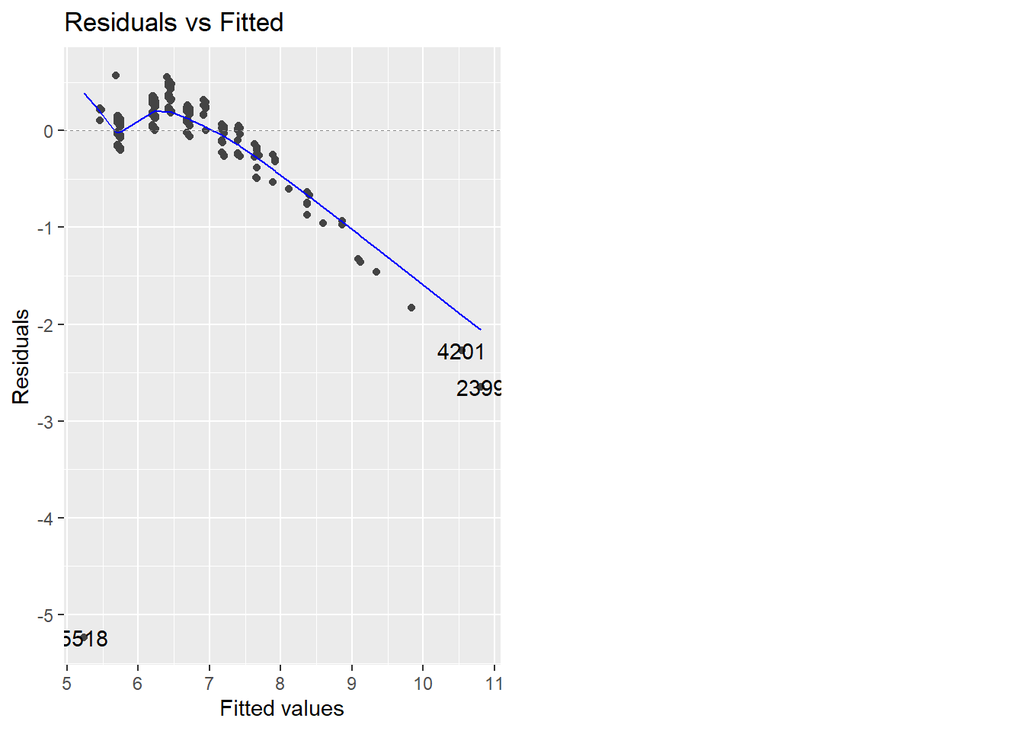

```r
autoplot(complexmodel_log, which = 1)
```

```r
# The line is somewhat more linear but it still has a little bump. The outlier values seem to drag the line downwards.
```

### Independence of residuals (Durbin-Watson test)

```r
dwtest(complexmodel_log)
```

```
##
##  Durbin-Watson test
##
## data:  complexmodel_log
## DW = 1.0616, p-value < 2.2e-16
## alternative hypothesis: true autocorrelation is greater than 0
```

```r
# Positive autocorrelation between residuals.
```

### Calculating VIF values for log-transformed complex model

```r
vif(complexmodel_log)
```

```
##        day_or_night          pump_count    pump_hours_total       domestic_wild
##            1.007624            1.743329            1.751184            1.006655
## borough_inner_outer
##            1.005628
```

```r
# VIF < 5, so these are okay
```

Still not perfect (maybe some improvement compared to the original complex model). I will compare both the original, both the log transformed models’ performance.

# 🐾 Model comparison 🐾

## Comparing the original null model with the original complex model

### Comparing model stats (AIC, F-statistic, p-value)

```r
# Null model stats
model_stats_nullmodel
```

```
## # A tibble: 5 × 2
##   Statistic                  Value
##   <chr>                      <dbl>
## 1 Adjusted R-squared    -0.0000851
## 2 F-statistic            0.393
## 3 p-value                0.531
## 4 Degrees of Freedom     1
## 5 AIC                95584.
```

```r
# Complex model stats
model_stats_complexmodel
```

```
## # A tibble: 5 × 2
##   Statistic              Value
##   <chr>                  <dbl>
## 1 Adjusted R-squared     0.948
## 2 F-statistic        25781.
## 3 p-value                0
## 4 Degrees of Freedom     5
## 5 AIC                74557.
```

```r
# Comparing AIC-values: the complex model has lower AIC (better)
AIC_nullmodel
```

```
## [1] 95583.83
```

```r
AIC_complexmodel
```

```
## [1] 74556.91
```

```r
# Comparing F-values of the models: the complex model has higher F-statistic (better)
f_statistic_nullmodel
```

```
##    value
## 0.393224
```

```r
f_statistic_complexmodel
```

```
##    value
## 25781.35
```

```r
# Comparing p-values of the models: the complex model has lower p-value (better)
p_value_nullmodel
```

```
##     value
## 0.5306297
```

```r
p_value_complexmodel
```

```
## value
##     0
```

The complex model seems to have better performance, because it has lower AIC and p-value and higher F-statistic.

### Coefficient interpretation

```r
coeff_extracted_nullmodel
```

```
## # A tibble: 2 × 6
##   term           estimate conf.low conf.high p.value standardized
##   <chr>             <dbl>    <dbl>     <dbl>   <dbl>        <dbl>
## 1 (Intercept)      357.      352.     363.     0         NA
## 2 domestic_wild1    -3.22    -13.3      6.84   0.531     -0.00743
```

```r
coeff_extracted_complexmodel
```

```
## # A tibble: 6 × 6
##   term                 estimate conf.low conf.high  p.value standardized
##   <chr>                   <dbl>    <dbl>     <dbl>    <dbl>        <dbl>
## 1 (Intercept)            30.0     22.1       37.9  1.31e-13     NA
## 2 day_or_night            2.34     0.117      4.56 3.91e- 2      0.00562
## 3 pump_count            -36.2    -45.1      -27.3  1.98e-15     -0.0285
## 4 pump_hours_total      304.     302.       306.   0             0.993
## 5 domestic_wild1         11.8      9.53      14.2  1.29e-23      0.0273
## 6 borough_inner_outer1   -0.612   -2.75       1.52 5.74e- 1     -0.00153
```

In the null model, the animal type was not a significant predictor of rescue cost.

In the more complex model:  
- day_or_night: significant predicor (night rescues more expensive)  
- pump_count: significant preditor (more pumps - less expensive)  
- pump_hours_total: significant predictor (longer rescue - more expensive)  
- domestic_wild: significant predictor (wild animals - more expensive)  
- borough_inner_outer: not significant (outer borough - cheaper)

My hypothesis (rescuing non-domestic animals is more expensive) seem to be supported.

## Comparing the log-transformed null model with the log-transformed complex model

### Comparing model stats (AIC, F-statistic, p-value)

```r
# Null model stats
model_stats_nullmodel_log
```

```
## # A tibble: 5 × 2
##   Statistic                 Value
##   <chr>                     <dbl>
## 1 Adjusted R-squared   -0.0000344
## 2 F-statistic           0.754
## 3 p-value               0.385
## 4 Degrees of Freedom    1
## 5 AIC                4411.
```

```r
# Complex model stats
model_stats_complexmodel_log
```

```
## # A tibble: 5 × 2
##   Statistic              Value
##   <chr>                  <dbl>
## 1 Adjusted R-squared     0.762
## 2 F-statistic         4562.
## 3 p-value                0
## 4 Degrees of Freedom     5
## 5 AIC                -5818.
```

```r
# Comparing AIC-values: the complex model has lower AIC (better)
# Both are better than the original models without log-transformation.
AIC_nullmodel_log
```

```
## [1] 4410.837
```

```r
AIC_complexmodel_log
```

```
## [1] -5817.918
```

```r
# Comparing F-values of the models: the complex model has higher F-statistic (better)
# The original complex model has higher F-value
f_statistic_nullmodel_log
```

```
##     value
## 0.7544938
```

```r
f_statistic_complexmodel_log
```

```
##    value
## 4562.163
```

```r
# Comparing p-values of the models: the complex model has lower p-value (better)
# Log-transformed null model has lower p-value than original, the complex models are both p = 0
p_value_nullmodel_log
```

```
##     value
## 0.3850864
```

```r
p_value_complexmodel_log
```

```
## value
##     0
```

The complex model seems to have better performance, because it has lower AIC and p-value and higher F-statistic. Compared to the original models, the log-transformed models don’t outperform them definitely.

### Coefficient interpretation

```r
coeff_extracted_nullmodel_log
```

```
## # A tibble: 2 × 6
##   term           estimate conf.low conf.high p.value standardized
##   <chr>             <dbl>    <dbl>     <dbl>   <dbl>        <dbl>
## 1 (Intercept)     5.81     5.80       5.81     0          NA
## 2 domestic_wild1  0.00747 -0.00939    0.0243   0.385       0.0103
```

```r
coeff_extracted_complexmodel_log
```

```
## # A tibble: 6 × 6
##   term                 estimate conf.low conf.high  p.value standardized
##   <chr>                   <dbl>    <dbl>     <dbl>    <dbl>        <dbl>
## 1 (Intercept)           5.48     5.46       5.51   0            NA
## 2 day_or_night          0.00400 -0.00394    0.0119 3.23e- 1      0.00573
## 3 pump_count           -0.259   -0.291     -0.227  3.90e-56     -0.122
## 4 pump_hours_total      0.486    0.479      0.494  0             0.948
## 5 domestic_wild1        0.0311   0.0229     0.0394 1.59e-13      0.0429
## 6 borough_inner_outer1  0.00348 -0.00415    0.0111 3.71e- 1      0.00518
```

In the null model, the animal type was not a significant predictor of rescue cost.

In the more complex model:  
- day_or_night: not significant  
- pump_count: significant predictor (more pumps - less expensive)  
- pump_hours_total: significant predictor (longer rescue - more expensive)  
- domestic_wild: significant predictor (wild animals - more expensive)  
- borough_inner_outer: not significant

The coefficients’ results are similar to the results of the original models.

# 🐾 Closing remarks 🐾

I used OpenAI’s ChatGPT throughout this project for brainstorming ideas, generating code suggestions, and debugging. It also helped me to interpret the results. I always requested explanations for the generated code and tested it to make sure that it worked correctly and aligned with my analysis goals.

Thank you for reading my report!

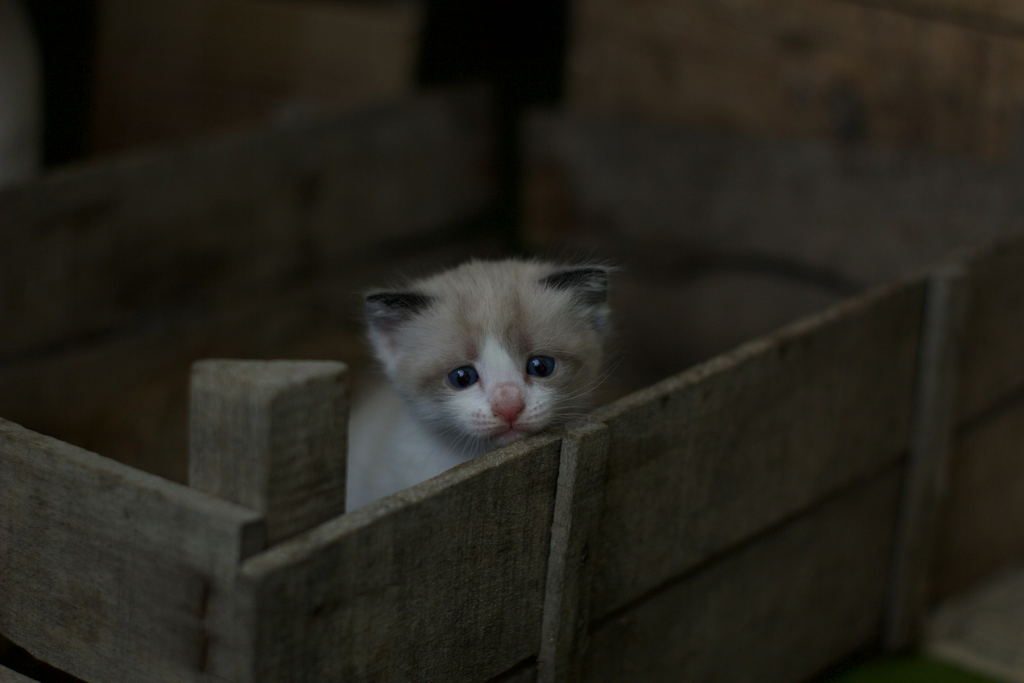

*Photo by George Bonev on Unsplash*